# cleaningdatapt1

#### Data Cleaning and Preparation

It is a good practice to start your document with the necessary packages.

```r
library(tidyverse)
library(skimr)
library(esquisse)
library(naniar) #visualizing missingness
library(mice) #imputation
```

#### Loading Our Data

Let’s load data from a CSV file. The file needs to be in our project’s Files pane (at right). Here we see a file called “penguins.csv”. We can then use the “read_csv” function to read-in this CSV file into a data frame:

```r
penguins = read_csv("penguins.csv")
```

```
──────────────────────────────────────────────────────── Delimiter: "," chr
(3): species, island, sex dbl (6): ...1, bill_length_mm, bill_depth_mm,
flipper_length_mm, body_mass_g...
```

#### Data Cleaning Tasks

Two of our key data cleaning tasks are:

1. Ensuring that variables are in the correct type
2. Dealing with missing data

Let’s start by looking at variable types. Here’s how the “tidyverse” package attempts to guess variable types when we read-in data (Note: “read_csv” is a “tidyverse” function).

- If a variable contains only F, T, FALSE, or TRUE, it will be typed as logical
- If it contains only numbers, it will be typed as numeric (or integer)
- If in a correct date (or date and time) format, it will be typed as a date or as date-time
- Otherwise, the variable is considered to be a string and is typed as a character

Look at the structure of our dataset to see how the variables in this dataset were typed when the dataset was read-in:

```r
str(penguins)
```

```
spc_tbl_ [344 × 9] (S3: spec_tbl_df/tbl_df/tbl/data.frame)
 $ ...1             : num [1:344] 1 2 3 4 5 6 7 8 9 10 ...
 $ species          : chr [1:344] "Adelie" "Adelie" "Adelie" "Adelie" ...
 $ island           : chr [1:344] "Torgersen" "Torgersen" "Torgersen" "Torgersen" ...
 $ bill_length_mm   : num [1:344] 39.1 39.5 40.3 NA 36.7 39.3 38.9 39.2 34.1 42 ...
 $ bill_depth_mm    : num [1:344] 18.7 17.4 18 NA 19.3 20.6 17.8 19.6 18.1 20.2 ...
 $ flipper_length_mm: num [1:344] 181 186 195 NA 193 190 181 195 193 190 ...
 $ body_mass_g      : num [1:344] 3750 3800 3250 NA 3450 ...
 $ sex              : chr [1:344] "male" "female" "female" NA ...
 $ year             : num [1:344] 2007 2007 2007 2007 2007 ...
 - attr(*, "spec")=
  .. cols(
  ..   ...1 = col_double(),
  ..   species = col_character(),
  ..   island = col_character(),
  ..   bill_length_mm = col_double(),
  ..   bill_depth_mm = col_double(),
  ..   flipper_length_mm = col_double(),
  ..   body_mass_g = col_double(),
  ..   sex = col_character(),
  ..   year = col_double()
  .. )
 - attr(*, "problems")=<externalptr>
```

The first variable “…1” is a variable that contains the row number of each observation in the dataset. We could delete this if we wish. The “species”, “island”, and “sex” variables are text so they are read-in as character variables. The other variables are numeric.

# level = category

# categorical variable = is a factor

# as_factor = converts into a factor

# comment on graph = describe what you see

The numeric variables are in the correct type, but we should consider converting the character variables. Here’s the key element of this: Is the variable categorical? If yes, it needs to be converted from a character to a **factor**. NOTE: Some variable that appear to be numeric are really categorical and should also be converted to factors. For example, if we had a variable representing high school grade (e.g., 9, 10, 11, and 12), it might make sense to convert these to factors as they could reasonably thought of as categorical.

Performing factor conversion with mutate and as_factor (do NOT use as.factor):

```r
penguins = penguins %>% mutate(species = as_factor(species)) %>%
  mutate(island = as_factor(island))%>%
  mutate(sex = as_factor(sex))
```

Check the structure to make sure that the conversion was done correctly:

```r
str(penguins)
```

```
tibble [344 × 9] (S3: tbl_df/tbl/data.frame)
 $ ...1             : num [1:344] 1 2 3 4 5 6 7 8 9 10 ...
 $ species          : Factor w/ 3 levels "Adelie","Gentoo",..: 1 1 1 1 1 1 1 1 1 1 ...
 $ island           : Factor w/ 3 levels "Torgersen","Biscoe",..: 1 1 1 1 1 1 1 1 1 1 ...
 $ bill_length_mm   : num [1:344] 39.1 39.5 40.3 NA 36.7 39.3 38.9 39.2 34.1 42 ...
 $ bill_depth_mm    : num [1:344] 18.7 17.4 18 NA 19.3 20.6 17.8 19.6 18.1 20.2 ...
 $ flipper_length_mm: num [1:344] 181 186 195 NA 193 190 181 195 193 190 ...
 $ body_mass_g      : num [1:344] 3750 3800 3250 NA 3450 ...
 $ sex              : Factor w/ 2 levels "male","female": 1 2 2 NA 2 1 2 1 NA NA ...
 $ year             : num [1:344] 2007 2007 2007 2007 2007 ...
```

With the variable types set correctly we can now develop visualizations and perform additional analysis.

```
Warning: Removed 2 rows containing non-finite values (`stat_boxplot()`).
```

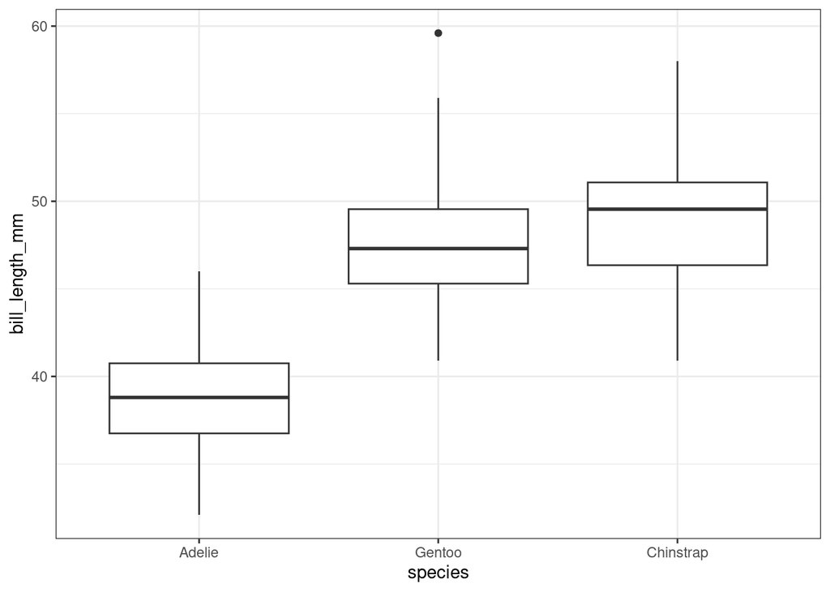

```r
ggplot(penguins,aes(x=species,y=bill_length_mm)) + geom_boxplot() + theme_bw()
```

Notice the warning at the top of the plot. This brings us to our next data cleaning issue: missing data.

What is **missing data**?

- Values in a dataset that are not available
- Missingness can be:
  - Legitimate –> Color of Car –> You Do Not Have a Car
  - Illegitimate –> Survey Question Skipped by Respondent
  - Missingness May Have Attributable Cause or May Be Random
  - Is “Unknown” the same thing as “Missing”?
  - unknown = unknowable :))))

What are the implications of missing data?